## Overview

Concordance analysis allows us to group strains that are genetically almost identical into an isotype. The following table summarizes the number of isotypes from previous and current releases, and the number of strains that belong to those isotypes.

|  | **Isotypes** | **Strains Included** | **Strains with WGS data** | **Strains with RAD-seq data** |
| --- | --- | --- | --- | --- |
| **Isotypes from Previous Release** | 327 | 779 | 639 | 140 |
| **New Isotypes from Current Release** | 76 | 134 | 134 | 0 |
| **Total** | 403 | 913 | 773 | 140 |

## Concordance score distribution and cutoff

We examined the pairwise concordance scores of all strains. Concordance values for every pair of strains were calculated as the number of shared variant sites divided by the total number of variants called for each pair. If the concordance score was more than 0.9995, the strain pair is grouped into the same isotype.

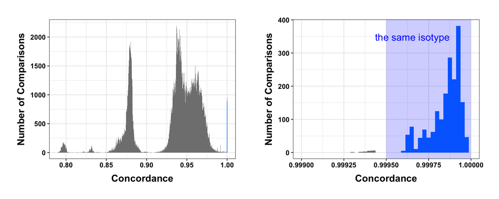

## Search for concordance for strain pairs

Strain comparisons are listed in the table below. Only concordance scores > 0.999 are shown.

| Strain | Strain | Total variants | Diff variants | Concordance | Is isotype |
| --- | --- | --- | --- | --- | --- |
| BRC20113 | BRC20067 | 3015190 | 172 | 0.999942955501975 | True |
| ECA1071 | ECA1070 | 3034068 | 238 | 0.999921557460149 | True |
| ECA1072 | ECA1070 | 3011082 | 223 | 0.999925940243408 | True |
| ECA1072 | ECA1071 | 3054395 | 257 | 0.999915858950791 | True |
| ECA1073 | ECA1070 | 3024539 | 192 | 0.999936519251364 | True |
| ECA1073 | ECA1071 | 3068393 | 232 | 0.999924390389367 | True |
| ECA1073 | ECA1072 | 3045361 | 197 | 0.999935311445835 | True |
| ECA1074 | ECA1070 | 3034616 | 244 | 0.999919594439626 | True |
| ECA1074 | ECA1071 | 3081128 | 209 | 0.999932167699622 | True |
| ECA1074 | ECA1072 | 3054280 | 235 | 0.999923058789633 | True |

[output cut: 1868 more lines]

## Changes from previous release

- Strain JU1511 was re-assigned to isotype JU792 from isotype JU1581. In the previous release (20180527), the JU1511 isotype grouping was based solely on RAD-seq data. We recently performed whole-genome sequencing of this strain and changed its isotype based on these new data.

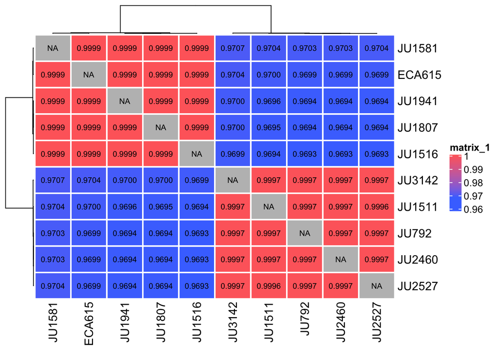

- Strain JU1580 was merged into the JU1793 isotype because it grouped with every strain of this isotype.

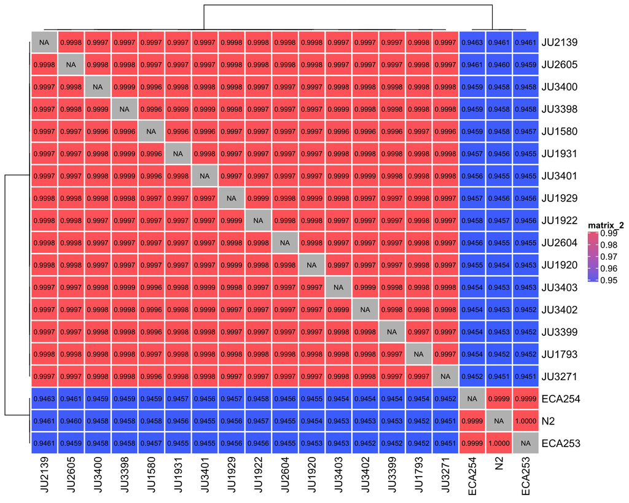